# Week 3 Homework

Kevin Hutchins

9/27/2021

Github Link: https://github.com/kevinkevink/Stat433/blob/main/HW3/HW3.html

## Question 1

How many flights have a missing dep_time? What other variables are missing? What might these rows represent?

```r
nrow(filter(flights, is.na(dep_time)))
```

```
## [1] 8255
```

8255 flights have a missing departure time.

After looking at the data using view(), it seems that if the departure time is missing, the delay, arrival time, arrival delay, and air time values are missing. This probably coincides with flights being canceled, as if a plane flight is canceled before take off, it will never fly and reach its destination. Plus, plane cancellations happen fairly often, which would explain why there are over 8000 of them.

```r
head(select(filter(flights, is.na(dep_time)), dep_time, dep_delay, arr_time, arr_delay, air_time), 50)
```

```
## # A tibble: 50 × 5
##    dep_time dep_delay arr_time arr_delay air_time
##       <int>     <dbl>    <int>     <dbl>    <dbl>
##  1       NA        NA       NA        NA       NA
##  2       NA        NA       NA        NA       NA
##  3       NA        NA       NA        NA       NA
##  4       NA        NA       NA        NA       NA
##  5       NA        NA       NA        NA       NA
##  6       NA        NA       NA        NA       NA
##  7       NA        NA       NA        NA       NA
##  8       NA        NA       NA        NA       NA
##  9       NA        NA       NA        NA       NA
## 10       NA        NA       NA        NA       NA
## # … with 40 more rows
```

## Question 2

Currently dep_time and sched_dep_time are convenient to look at, but hard to compute with because they’re not really continuous numbers. Convert them to a more convenient representation of number of minutes since midnight.

I converted dep_time into minutes and added it next to dep_time, labled as deptime. I also converted sched_dep_time into minutes and added the new column labled scheddeptime next to sched_dep_time.

```r
data = mutate(flights, deptime = ((dep_time - (dep_time %% 100)) * 0.6 + (dep_time %% 100)), scheddeptime = (sched_dep_time - (sched_dep_time %% 100)) * 0.6  +  (sched_dep_time %% 100)) %>% relocate(deptime, .after = dep_time) %>% relocate(scheddeptime, .after = sched_dep_time)
head(data, 100)
```

```
## # A tibble: 100 × 21
##     year month   day dep_time deptime sched_dep_time scheddeptime dep_delay
##    <int> <int> <int>    <int>   <dbl>          <int>        <dbl>     <dbl>
##  1  2013     1     1      517     317            515          315         2
##  2  2013     1     1      533     333            529          329         4
##  3  2013     1     1      542     342            540          340         2
##  4  2013     1     1      544     344            545          345        -1
##  5  2013     1     1      554     354            600          360        -6
##  6  2013     1     1      554     354            558          358        -4
##  7  2013     1     1      555     355            600          360        -5
##  8  2013     1     1      557     357            600          360        -3
##  9  2013     1     1      557     357            600          360        -3
## 10  2013     1     1      558     358            600          360        -2
## # … with 90 more rows, and 13 more variables: arr_time <int>,
## #   sched_arr_time <int>, arr_delay <dbl>, carrier <chr>, flight <int>,
## #   tailnum <chr>, origin <chr>, dest <chr>, air_time <dbl>, distance <dbl>,
## #   hour <dbl>, minute <dbl>, time_hour <dttm>
```

## Question 3

Look at the number of canceled flights per day. Is there a pattern? Is the proportion of canceled flights related to the average delay? Use multiple dyplr operations, all on one line, concluding with ggplot(aes(x= ,y=)) + geom_point()

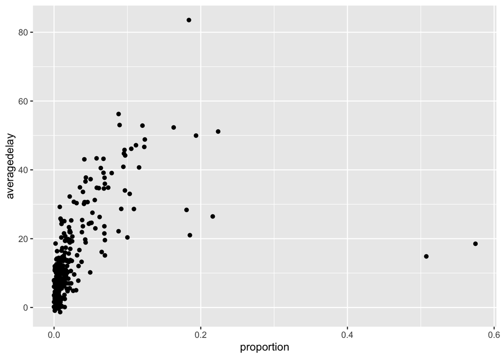

```r
flights %>% group_by(month, day) %>% summarize(proportion = sum(is.na(dep_time)) / n(), averagedelay = mean(dep_delay, na.rm = T)) %>% ggplot(aes(x= proportion,y=averagedelay)) + geom_point()
```

there seems to be some weak correlation between the average departure delay and number of canceled flights per day. It seems that the greater number of canceled flights there are, the greater the average departure delay is on average. This makes sense, as if there is bad weather, more flights will get canceled and more flights will be delayed during the weather which stops planes from flying.